# Data Cleaning for Analysis

Vorisek_CN

17 01 2022

# Prepare Data Cleaning

*Load relevant libraries*

```r
library(readxl)
library(tidyverse)
library(writexl)
library(knitr)
```

*Bar themes*

```r
# define theme and colors for barplots
bar_theme <-   theme(rect = element_blank(),
        axis.ticks.y = element_line(color = "grey40"),
        panel.grid.major.x = element_line(color = "grey90"))
bar_color <-  "#1b3051"
bar_width <- 0.6
```

*Read in file created in “Data_Preparation.Rmd”*

```r
merged <- read_excel("merged.xlsx")
View(merged)
```

**Entire Data**

```r
nrow(merged)
```

```
## [1] 638
```

```r
ncol(merged)
```

```
## [1] 139
```

# Delete Incomplete Datasets of AI Developers

## Questionnaire 1 completed

```r
complete1 <- merged[merged$fragebogen_fairness_und_ki_complete == 2, ]
nrow(complete1)
```

```
## [1] 441
```

## Who completed sheet 1?

```r
is.factor(complete1$ki_entwicklung)
```

```
## [1] FALSE
```

```r
complete1$ki_entwicklung = as.factor(complete1$ki_entwicklung)
```

```r
developer <- complete1 %>%
  group_by(ki_entwicklung) %>%
  summarize(N = n()) %>%
  mutate(Percent = N / sum(N) * 100,
         Percent = round(Percent, 1)) %>%
  arrange(desc(N))

#Rename Variables
developer$ki_entwicklung <- factor(developer$ki_entwicklung,levels = c(1,2,3,4,5), labels = c("Yes","No, but I have worked on AI-projects in the past", "No, but I am planning on it", "No, never", "Not specified"))

knitr::kable(developer)
```

| ki_entwicklung | N | Percent |
| --- | --- | --- |
| Yes | 214 | 48.5 |
| No, never | 94 | 21.3 |
| No, but I have worked on AI-projects in the past | 64 | 14.5 |
| No, but I am planning on it | 56 | 12.7 |
| Not specified | 13 | 2.9 |

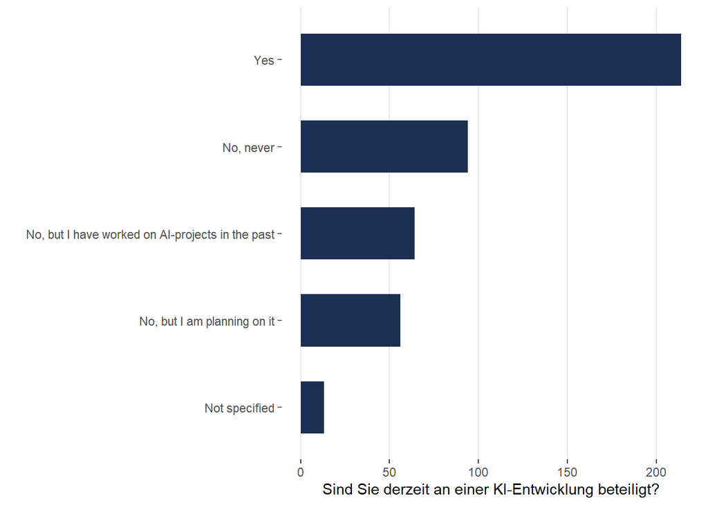

```r
ggplot(developer) + geom_col(aes(reorder(ki_entwicklung, N, sum), N),
                              fill = bar_color,
                              width = bar_width) +
  labs(x = "", y = "Sind Sie derzeit an einer KI-Entwicklung beteiligt?") +
  scale_y_continuous(breaks = seq(0,200,50)) +
  coord_flip() +
  bar_theme
```

## Data of AI Developers only

```r
AIcomplete1 <- complete1[complete1$ki_entwicklung == 1 | complete1$ki_entwicklung == 2 | complete1$ki_entwicklung == 3, ]
nrow(AIcomplete1)
```

```
## [1] 334
```

## Questionnaire 2 completed

```r
AIcomplete2 <- AIcomplete1[AIcomplete1$fragebogen_fairness_und_ki_2_complete == 2, ]
nrow(AIcomplete2)
```

```
## [1] 199
```

## response rate

```r
199/334*100
```

```
## [1] 59.58084
```

# Identify additional Incomplete IDs

*“Show only fields” are not included to identify missing data, evaluation in a second step*

**Demographics**

*Prepare Data*

```r
AIcomplete2$arbeitsland = as.factor(AIcomplete2$arbeitsland)
AIcomplete2$geschlecht = as.factor(AIcomplete2$geschlecht)
AIcomplete2$sektor = as.factor(AIcomplete2$sektor)
AIcomplete2$quelle = as.factor(AIcomplete2$quelle)
AIcomplete2$alter = as.numeric(AIcomplete2$alter)
```

## How did this questionnaire reach you?

```r
nrow(AIcomplete2)
```

```
## [1] 199
```

```r
AIcomplete2 <- AIcomplete2 %>% drop_na(quelle)
nrow(AIcomplete2)
```

```
## [1] 199
```

## Which country do you work in?

```r
nrow(AIcomplete2)
```

```
## [1] 199
```

```r
AIcomplete2 <- AIcomplete2 %>% drop_na(arbeitsland)
nrow(AIcomplete2)
```

```
## [1] 199
```

## What is your gender?

```r
nrow(AIcomplete2)
```

```
## [1] 199
```

```r
AIcomplete2 <- AIcomplete2 %>% drop_na(geschlecht)
nrow(AIcomplete2)
```

```
## [1] 195
```

## what is your age?

```r
nrow(AIcomplete2)
```

```
## [1] 195
```

```r
AIcomplete2 <- AIcomplete2 %>% drop_na(alter)
nrow(AIcomplete2)
```

```
## [1] 185
```

## In which area do you work in?

```r
nrow(AIcomplete2)
```

```
## [1] 185
```

```r
AIcomplete2 <- AIcomplete2 %>% drop_na(sektor)
nrow(AIcomplete2)
```

```
## [1] 183
```

## At what stage are you or have you been developing AI-projects?

```r
which(colnames(AIcomplete2) == "ki_entwicklungsphase___1")
```

```
## [1] 19
```

```r
which(colnames(AIcomplete2) == "ki_entwicklungsphase___8")
```

```
## [1] 26
```

*create dataset*

```r
data_ID<-AIcomplete2 %>% select(1, 19:26)
view(data_ID)
ncol(data_ID)
```

```
## [1] 9
```

**identify incomplete IDs**

```r
data_ID <- data_ID %>%
    mutate(nonresp = select(., 2:9) %>% rowSums(na.rm = TRUE))
incomplete <- data_ID[data_ID$nonresp == 0, ]
incomplete$id
```

```
## [1] 136 439 625
```

*drop non resp*

```r
nrow(AIcomplete2)
```

```
## [1] 183
```

```r
AIcomplete2 <-AIcomplete2[!(AIcomplete2$id==136 | AIcomplete2$id==439 | AIcomplete2$id==625),]
nrow(AIcomplete2)
```

```
## [1] 180
```

```r
rm(data_ID)
rm(incomplete)
```

## In which medical specialty are you developing AI solutions?

```r
which(colnames(AIcomplete2) == "med_fachbereich___1")
```

```
## [1] 28
```

```r
which(colnames(AIcomplete2) == "med_fachbereich___37")
```

```
## [1] 64
```

*create dataset*

```r
data_ID<-AIcomplete2 %>% select(1, 28:64)
view(data_ID)
ncol(data_ID)
```

```
## [1] 38
```

*identify incomplete IDs*

```r
data_ID <- data_ID %>%
    mutate(nonresp = select(., 2:38) %>% rowSums(na.rm = TRUE))
incomplete <- data_ID[data_ID$nonresp == 0, ]
incomplete$id
```

```
## [1]  36 143 278 567 609
```

*drop non resp*

```r
nrow(AIcomplete2)
```

```
## [1] 180
```

```r
AIcomplete2 <- AIcomplete2[!(AIcomplete2$id==36 | AIcomplete2$id==143 | AIcomplete2$id==278 | AIcomplete2$id==567 | AIcomplete2$id==609),]
nrow(AIcomplete2)
```

```
## [1] 175
```

```r
rm(data_ID)
rm(incomplete)
```

## In which of the following areas of AI are you developing?

```r
which(colnames(AIcomplete2) == "ki_art___1")
```

```
## [1] 66
```

```r
which(colnames(AIcomplete2) == "ki_art___4")
```

```
## [1] 69
```

*create dataset*

```r
data_ID<-AIcomplete2 %>% select(1,  66:69)
view(data_ID)
ncol(data_ID)
```

```
## [1] 5
```

*identify incomplete IDs*

```r
data_ID <- data_ID %>%
    mutate(nonresp = select(., 2:5) %>% rowSums(na.rm = TRUE))
incomplete <- data_ID[data_ID$nonresp == 0, ]
incomplete$id
```

```
## [1] 316 366
```

*drop non resp*

```r
nrow(AIcomplete2)
```

```
## [1] 175
```

```r
AIcomplete2 <- AIcomplete2[!(AIcomplete2$id==316  | AIcomplete2$id==366),]
nrow(AIcomplete2)
```

```
## [1] 173
```

```r
rm(data_ID)
rm(data_ID)
```

## In which of the following areas of AI are you developing?

```r
which(colnames(AIcomplete2) == "ki_bereich___1")
```

```
## [1] 81
```

```r
which(colnames(AIcomplete2) == "ki_bereich___7")
```

```
## [1] 87
```

*create dataset*

```r
data_ID <-AIcomplete2 %>% select(1,  81:87)
view(data_ID)
ncol(data_ID)
```

```
## [1] 8
```

*identify incomplete IDs*

```r
data_ID <- data_ID %>%
    mutate(nonresp = select(., 2:8) %>% rowSums(na.rm = TRUE))
incomplete <- data_ID[data_ID$nonresp == 0, ]
incomplete$id
```

```
## [1] 231 351 357 560
```

*drop non resp*

```r
nrow(AIcomplete2)
```

```
## [1] 173
```

```r
AIcomplete2 <- AIcomplete2[!(AIcomplete2$id==231  | AIcomplete2$id==351  | AIcomplete2$id==357 | AIcomplete2$id==560),]
nrow(AIcomplete2)
```

```
## [1] 169
```

```r
rm(data_ID)
rm(incomplete)
```

```r
nrow(AIcomplete2)
```

```
## [1] 169
```

```r
AIcomplete2 <- AIcomplete2 %>% drop_na(bias_ki)
nrow(AIcomplete2)
```

```
## [1] 167
```

## Where do you think biases in AI can occur?

```r
which(colnames(AIcomplete2) == "bias_feld___1")
```

```
## [1] 90
```

```r
which(colnames(AIcomplete2) == "bias_feld___6")
```

```
## [1] 95
```

*create dataset*

```r
data_ID <-AIcomplete2 %>% select(1,  90:95)
view(data_ID)
ncol(data_ID)
```

```
## [1] 7
```

*identify incomplete IDs*

```r
data_ID <- data_ID %>%
    mutate(nonresp = select(., 2:7) %>% rowSums(na.rm = TRUE))
incomplete <- data_ID[data_ID$nonresp == 0, ]
incomplete$id
```

```
## [1] 247 257 269 290 382 422 624
```

*drop non resp*

```r
nrow(AIcomplete2)
```

```
## [1] 167
```

```r
AIcomplete2 <- AIcomplete2[!(AIcomplete2$id==247   | AIcomplete2$id==257   | AIcomplete2$id==269  | AIcomplete2$id==290  | AIcomplete2$id==382    | AIcomplete2$id==422   | AIcomplete2$id==624),]
nrow(AIcomplete2)
```

```
## [1] 160
```

```r
rm(data_ID)
rm(incomplete)
```

## What data do you use to train AI algorithms?

```r
which(colnames(AIcomplete2) == "ki_trainingsdaten___1")
```

```
## [1] 97
```

```r
which(colnames(AIcomplete2) == "ki_trainingsdaten___4")
```

```
## [1] 100
```

*create dataset*

```r
data_ID <-AIcomplete2 %>% select(1, 97:100)
view(data_ID)
ncol(data_ID)
```

```
## [1] 5
```

*identify incomplete IDs*

```r
data_ID <- data_ID %>%
    mutate(nonresp = select(., 2:5) %>% rowSums(na.rm = TRUE))
incomplete <- data_ID[data_ID$nonresp == 0, ]
incomplete$id
```

```
## [1] 214 330 587
```

*drop non resp*

```r
nrow(AIcomplete2)
```

```
## [1] 160
```

```r
AIcomplete2 <- AIcomplete2[!(AIcomplete2$id==214    | AIcomplete2$id==330    | AIcomplete2$id==587),]
nrow(AIcomplete2)
```

```
## [1] 157
```

```r
rm(data_ID)
rm(incomplete)
```

## What is the origin of your data?

```r
which(colnames(AIcomplete2) == "ki_daten_quelle___1")
```

```
## [1] 101
```

```r
which(colnames(AIcomplete2) == "ki_daten_quelle___6")
```

```
## [1] 106
```

*create dataset*

```r
data_ID <-AIcomplete2 %>% select(1, 101:106)
view(data_ID)
ncol(data_ID)
```

```
## [1] 7
```

*identify incomplete IDs*

```r
data_ID <- data_ID %>%
    mutate(nonresp = select(., 2:7) %>% rowSums(na.rm = TRUE))
incomplete <- data_ID[data_ID$nonresp == 0, ]
incomplete$id
```

```
## [1] 152
```

*drop non resp*

```r
nrow(AIcomplete2)
```

```
## [1] 157
```

```r
AIcomplete2 <- AIcomplete2[!(AIcomplete2$id==152),]
nrow(AIcomplete2)
```

```
## [1] 156
```

```r
rm(data_ID)
rm(incomplete)
```

## Do you work with national or international data?

```r
nrow(AIcomplete2)
```

```
## [1] 156
```

```r
AIcomplete2 <- AIcomplete2 %>% drop_na(nat_internat_daten)
nrow(AIcomplete2)
```

```
## [1] 156
```

## Do you think that using standardized data (internationalsemantic and syntactic standards such as HL7 FHIR, SNOMEDCT) when training AI algorithms can prevent bias?

```r
nrow(AIcomplete2)
```

```
## [1] 156
```

```r
AIcomplete2 <- AIcomplete2 %>% drop_na(standard_daten)
nrow(AIcomplete2)
```

```
## [1] 153
```

## Do you know any of the following preventive measures to avoidbias in AI applications?

```r
which(colnames(AIcomplete2) == "massnahmen_bias___1")
```

```
## [1] 110
```

```r
which(colnames(AIcomplete2) == "massnahmen_bias___6")
```

```
## [1] 115
```

*create dataset*

```r
data_ID <-AIcomplete2 %>% select(1, 110:115)
view(data_ID)
ncol(data_ID)
```

```
## [1] 7
```

*identify incomplete IDs*

```r
data_ID <- data_ID %>%
    mutate(nonresp = select(., 2:7) %>% rowSums(na.rm = TRUE))
incomplete <- data_ID[data_ID$nonresp == 0, ]
incomplete$id
```

```
## [1] 529  28
```

*drop non resp*

```r
nrow(AIcomplete2)
```

```
## [1] 153
```

```r
AIcomplete2 <- AIcomplete2[!(AIcomplete2$id==529      | AIcomplete2$id==28),]
nrow(AIcomplete2)
```

```
## [1] 151
```

```r
rm(data_ID)
rm(incomplete)
```

## What sociodemographic data would you collect to prevent biases in AI?

```r
which(colnames(AIcomplete2) == "soziodem_daten___1")
```

```
## [1] 117
```

```r
which(colnames(AIcomplete2) == "soziodem_daten___7")
```

```
## [1] 123
```

*create dataset*

```r
data_ID <-AIcomplete2 %>% select(1, 117:123)
view(data_ID)
ncol(data_ID)
```

```
## [1] 8
```

*identify incomplete IDs*

```r
data_ID <- data_ID %>%
    mutate(nonresp = select(., 2:8) %>% rowSums(na.rm = TRUE))
incomplete <- data_ID[data_ID$nonresp == 0, ]
incomplete$id
```

```
## numeric(0)
```

*drop non resp*

```r
rm(data_ID)
rm(incomplete)
```

## How would you rate the level of fairness of AI in your AIdevelopment? (Are specifi c groups of people treated /considereddiff erently from others?)

```r
nrow(AIcomplete2)
```

```
## [1] 151
```

```r
AIcomplete2 <- AIcomplete2 %>% drop_na(fairness_ki)
nrow(AIcomplete2)
```

```
## [1] 151
```

# Create File for Analysis

```r
write_xlsx(AIcomplete2, 'AnalysisFile_Bias_AI.xlsx')
```